# Supporting Information for

## Condensation reaction (Supplementary Discussion 1)

Calculations performed with AIQM1, which is known to produce accurate thermochemistry approaching chemical accuracy.

```python
print_reaction_summary([benzylamine, benzylamine], [N_benzylidenebenzylamine, NH3, H2])
```

```
ΔE = 18.7 kcal/mol
ΔE+ZPVE = 7.6 kcal/mol
ΔH = 10.2 kcal/mol
ΔG = 2.7 kcal/mol
```

## Cartesian coordinates, energies, number of imaginary frequencies in optimized structures, excited-state properties

Below, we extract the basic information from the calculations. More information is contained in the raw output files and MLatom data formats saved in json files. How to use MLatom to check the calculation results are also shown above and below.

```python
def print_summary(mol):
    import pandas as pd
    import numpy as np
    print(f'Total energy: {mol.energy:.13f} Hartree')
    print(f'ZPE:           {mol.ZPE:.7f} Hartree')
    print(f'H:            {mol.H:.7f} Hartree')
    print(f'G:            {mol.G:.7f} Hartree')
    print()
    nimag = np.sum(np.array(mol.frequencies) < 0)
    print(f'Number of imaginary frequencies: {nimag}')
    if nimag > 0:
        print(f'Lowest 10 frequencies: {mol.frequencies[:10]}')
    print()
    print(f'XYZ coordinates in Angstrom\n')
    with pd.option_context("display.max_rows", None, "display.max_columns", None):
        print(pd.DataFrame(mol.get_xyz_coordinates(), mol.get_element_symbols(), columns=list("XYZ")))
    mol.view(width=600)
```

```python
import pandas as pd
from IPython.display import display, HTML
def get_table_mo_contributions(molecule):
    import numpy as np
    ex_strs = []; eVs = []; nms = []; fs = []; max_contribs = []
    for istate, state in enumerate(molecule.electronic_states[1:]):
        abs_coeffs = [abs(contrib['coeff']) for contrib in state.mo_contributions]
        maxcontrib = np.argmax(np.array(abs_coeffs))
        coeff = state.mo_contributions[maxcontrib]['coeff']

        unrestricted = {'A': u'\u03B1', 'B': u'\u03B2'}
        fromMO = u''
        nfromMO = 0
        spin = 'all'
        nOMOs = {'all': molecule.n_occ_mos, 'A': 0, 'B': 0}
        nfromMO = state.mo_contributions[maxcontrib]['from']
        fromMO += u'H'
        if nfromMO != nOMOs[spin]:
            fromMO += u'\u2212%d' % abs(nfromMO - nOMOs[spin])
        toMO = u''
        ntoMO = 0
        ntoMO = state.mo_contributions[maxcontrib]['to']
        toMO += u'L'
        if ntoMO != nOMOs[spin]+1:
            toMO += u'%+d' % (ntoMO - nOMOs[spin]-1)

        largest_contribution = u'%s \u2192 %s (%.2f)' % (fromMO, toMO, coeff)
        eV = molecule.excitation_energies[istate] * ml.constants.hartree2eV
        nm = ml.constants.eV2nm(eV)
        f = molecule.oscillator_strengths[istate]
        spins = {1: 'S', 2: 'D', 3: 'T', 4: 'Q'}
        mult = state.multiplicity
        ex_str = ''
        if mult in spins.keys():
            ex_str = f'{spins[mult]}{istate+1}'
        else:
            ex_str = f'{istate+1}'
        ex_strs.append(ex_str)
        eVs.append(eV)
        nms.append(nm)
        fs.append(f)
        max_contribs.append(largest_contribution)
    ex_df = pd.DataFrame({'Excitation': ex_strs,
                       'E, eV': eVs,
                       '𝜆, nm': nms,
                       'f': fs,
                       'Largest contribution': max_contribs})
    ex_df['E, eV'] = ex_df['E, eV'].apply(lambda x: f'{x:.2f}')
    ex_df['𝜆, nm'] = ex_df['𝜆, nm'].apply(lambda x: f'{x:.0f}')
    ex_df['f'] = ex_df['f'].apply(lambda x: f'{x:.2f}')

    print(f'The excitation energies (E), wavelength (𝜆), oscillator strengths (f),\nand the largest Kohn–Sham molecular orbital transition contributions (in parenthesis)\nfor the key vertical excitations. H – denotes HOMO, L – LUMO.')
    display(HTML(ex_df.to_html(escape=False, index=False)))
```

### PHI···TEA

#### wB97X-D/def2-SVP (in acetonitrile, CPCM implicit solvent model)

```python
print_summary(phi_tea)
# note that it has one tiny negative frequency, which is common for such big noncovalent complexes, hence, we ignore it
```

```
Total energy: -1885.8568710000000 Hartree
ZPE:           0.4890920 Hartree
H:            -1885.3324960 Hartree
G:            -1885.4352320 Hartree

Number of imaginary frequencies: 1
Lowest 10 frequencies: [-6.4115, 16.064, 20.2781, 27.3806, 35.2319, 40.8566, 50.0882, 55.1043, 70.7429, 88.0629]

XYZ coordinates in Angstrom

          X         Y         Z
C -5.398519  0.624172  1.035888
C -6.103759 -1.510157  1.407465
C -4.001311 -1.304332  0.565494
C -4.538173  2.688098  0.599817
C -3.168314  0.934410  0.129458
C -1.921532 -0.912086 -0.265993
N -6.350209 -0.190952  1.450887
N -5.556893  1.935613  1.041935
N -4.966628 -2.094558  0.980923
N -4.185870  0.083930  0.575468
N -3.352055  2.234591  0.143266
N -2.842647 -1.790621  0.135266
N -2.023868  0.404600 -0.300261
N -0.748690 -1.527640 -0.655351
C  0.466316 -1.040909 -1.055614
N  1.414634 -1.992265 -1.086791
C  2.638952 -1.614793 -1.389136
C  1.839567  0.657709 -1.656731
N  2.894332 -0.265455 -1.655102
C  4.199844  0.175573 -1.912918
N  0.613892  0.236562 -1.361960
N  4.424742  1.445956 -2.145077
N  2.082311  1.920487 -1.927588
N  5.186349 -0.719573 -1.904325
N  3.644271 -2.480838 -1.425802
C  3.361358  2.275406 -2.148053
C  4.847308 -1.978129 -1.674846
H -0.756131 -2.532487 -0.508764
N -4.707557  4.009281  0.609725
```

[output cut: 19 more lines]

```
C  4.216090  2.456911  1.461117
H  5.031690  1.746603  1.256824
H  4.171864  3.159652  0.615531
H  4.475892  3.022029  2.369141
C  0.533357 -0.139509  2.255245
H -0.465899 -0.285611  2.694244
H  0.397849  0.422958  1.319204
H  0.934984 -1.133397  2.006995
C  3.907014 -1.089227  1.722920
H  4.644378 -1.874688  1.945880
H  2.957503 -1.580527  1.467381
H  4.271371 -0.553293  0.832875
C  7.146959 -2.584857 -1.908761
N  8.262902 -2.339041 -2.098964
H  2.646922  1.192831  0.703823
```

3Dmol.js failed to load for some reason. Please check your browser console for error messages.

#### TD-wB97X-D/def2-SVP (in acetonitrile, CPCM implicit solvent model) on ground-state wB97X-D/def2-SVP-optimized geometries

```python
get_table_mo_contributions(phi_tea_es)
```

```
The excitation energies (E), wavelength (𝜆), oscillator strengths (f),
and the largest Kohn–Sham molecular orbital transition contributions (in parenthesis)
for the key vertical excitations. H – denotes HOMO, L – LUMO.
```

| Excitation | E, eV | 𝜆, nm | f | Largest contribution |
| --- | --- | --- | --- | --- |
| S1 | 3.97 | 312 | 0.03 | H−2 → L (0.58) |
| S2 | 4.06 | 306 | 0.01 | H → L (0.57) |
| S3 | 4.09 | 303 | 0.03 | H−1 → L (0.40) |
| S4 | 4.51 | 275 | 0.01 | H−5 → L (0.54) |
| S5 | 4.81 | 258 | 2.56 | H−4 → L (0.50) |
| S6 | 4.83 | 257 | 0.01 | H → L+1 (0.65) |
| S7 | 4.91 | 252 | 0.00 | H−12 → L (0.46) |
| S8 | 5.01 | 248 | 0.01 | H → L+2 (0.64) |
| S9 | 5.04 | 246 | 0.01 | H−13 → L (0.34) |
| S10 | 5.07 | 245 | 0.01 | H−13 → L (0.30) |
| S11 | 5.14 | 241 | 0.00 | H−7 → L (0.36) |
| S12 | 5.16 | 240 | 1.15 | H−2 → L+1 (0.51) |
| S13 | 5.19 | 239 | 0.00 | H−9 → L (0.35) |
| S14 | 5.21 | 238 | 0.57 | H−1 → L+3 (0.46) |
| S15 | 5.42 | 229 | 0.04 | H−2 → L+2 (0.58) |
| S16 | 5.52 | 225 | 0.01 | H−10 → L+1 (0.31) |
| S17 | 5.52 | 224 | 0.15 | H−1 → L+4 (0.59) |
| S18 | 5.59 | 222 | 0.01 | H−5 → L+2 (0.33) |
| S19 | 5.65 | 220 | 0.35 | H−6 → L (0.45) |
| S20 | 5.67 | 219 | 0.01 | H−9 → L+5 (0.37) |
| S21 | 5.68 | 218 | 0.34 | H−3 → L (0.46) |
| S22 | 5.70 | 217 | 0.00 | H−7 → L+5 (0.33) |
| S23 | 5.82 | 213 | 0.00 | H−5 → L+4 (0.43) |
| S24 | 5.85 | 212 | 0.00 | H−13 → L+1 (0.27) |
| S25 | 5.86 | 212 | 0.00 | H → L+3 (0.48) |
| S26 | 5.89 | 211 | 0.04 | H−8 → L (0.33) |
| S27 | 5.98 | 207 | 0.03 | H−8 → L (0.31) |
| S28 | 6.08 | 204 | 0.01 | H−17 → L (0.27) |
| S29 | 6.09 | 203 | 0.04 | H−6 → L+1 (0.45) |
| S30 | 6.17 | 201 | 0.39 | H−3 → L+3 (0.43) |

### PHI(2e<sup>-</sup>/H<sup>+</sup>)···Im<sup>+</sup>

#### wB97X-D/def2-SVP (in acetonitrile, CPCM implicit solvent model), S<sub>0</sub>

```python
print_summary(eda)
```

```
Total energy: -1885.7600786000000 Hartree
ZPE:           0.4878560 Hartree
H:            -1885.2353400 Hartree
G:            -1885.3421360 Hartree

Number of imaginary frequencies: 0

XYZ coordinates in Angstrom

          X         Y         Z
C  3.154519  0.675140  2.659255
C  4.776820 -0.558325  1.642010
C  2.905886 -0.184497  0.399236
C  1.440420  1.906288  3.519384
C  1.120279  1.115629  1.406268
C  0.966280  0.277400 -0.702776
N  4.350509  0.119318  2.721367
N  2.659968  1.365935  3.671226
N  4.105445 -0.726962  0.489536
N  2.390086  0.530564  1.490859
N  0.655957  1.810143  2.430159
N  2.176843 -0.299971 -0.698482
N  0.415196  0.971779  0.297161
N  0.280286  0.156937 -1.864520
C -0.985669  0.722270 -2.139329
N -1.964680  0.402324 -1.359910
C -3.170260  1.026705 -1.549947
C -2.080283  2.239281 -3.425134
N -3.201923  2.000054 -2.638940
C -4.266251  2.889023 -2.688452
N -0.972581  1.551975 -3.213858
N -4.280534  3.884088 -3.558422
N -2.127662  3.188746 -4.356045
N -5.253851  2.680040 -1.842856
N -4.201023  0.809365 -0.840324
C -3.222808  3.960242 -4.387869
C -5.436811  1.415985 -1.074393
H  0.843220 -0.106622 -2.666438
N  0.960862  2.607323  4.548758
N -3.267853  4.914686 -5.327151
```

[output cut: 18 more lines]

```
C -4.018516  5.733957  3.409664
H -4.345173  6.649916  2.908252
H -4.867610  5.039826  3.500835
H -3.676017  5.964390  4.428670
C -1.763994  3.709206 -0.259912
H -0.950358  3.024372 -0.532958
H -2.663377  3.106940 -0.070469
H -1.950837  4.390294 -1.103157
C -4.290767  5.968499  0.020432
H -4.606487  6.800139 -0.623838
H -4.190811  5.067982 -0.599568
H -5.082159  5.781777  0.758870
C -5.410027  2.391465  1.142633
N -4.746039  2.938994  1.931176
H -6.062975  3.277303 -1.974508
```

3Dmol.js failed to load for some reason. Please check your browser console for error messages.

#### TD-wB97X-D/def2-SVP (in acetonitrile, CPCM implicit solvent model) on ground-state wB97X-D/def2-SVP-optimized geometries

```python
get_table_mo_contributions(eda_es)
```

```
The excitation energies (E), wavelength (𝜆), oscillator strengths (f),
and the largest Kohn–Sham molecular orbital transition contributions (in parenthesis)
for the key vertical excitations. H – denotes HOMO, L – LUMO.
```

| Excitation | E, eV | 𝜆, nm | f | Largest contribution |
| --- | --- | --- | --- | --- |
| S1 | 2.27 | 546 | 0.07 | H → L+5 (0.46) |
| S2 | 2.90 | 428 | 0.05 | H → L+5 (0.46) |
| S3 | 3.27 | 379 | 0.00 | H → L+1 (0.69) |

#### wB97X-D/def2-SVP (in acetonitrile, CPCM implicit solvent model), T<sub>1</sub>

```python
print_summary(eda_t1)
```

```
Total energy: -1885.7620176999999 Hartree
ZPE:           0.4839820 Hartree
H:            -1885.2405270 Hartree
G:            -1885.3506300 Hartree

Number of imaginary frequencies: 0

XYZ coordinates in Angstrom

          X         Y         Z
C  2.876981  1.026413  2.648695
C  4.596296 -0.109061  1.674852
C  2.788752  0.257459  0.339771
C  1.064858  2.149283  3.462998
C  0.906005  1.446191  1.299937
C  0.896961  0.715406 -0.847817
N  4.086351  0.505668  2.755982
N  2.299562  1.654210  3.658665
N  3.999347 -0.250797  0.478285
N  2.191534  0.910898  1.428375
N  0.349265  2.052816  2.324238
N  2.124232  0.168036 -0.800572
N  0.267581  1.335470  0.143142
N  0.288322  0.588537 -2.058935
C -0.945358  1.021974 -2.535230
N -1.772752  1.693916 -1.782890
C -2.932258  2.080242 -2.301696
C -2.256964  1.004573 -4.412651
N -3.214990  1.735787 -3.676871
C -4.383305  2.096772 -4.279391
N -1.137141  0.654077 -3.844694
N -4.669459  1.801767 -5.508410
N -2.543295  0.697513 -5.680316
N -5.262251  2.800496 -3.516820
N -3.851332  2.776726 -1.623868
C -3.710119  1.093823 -6.178151
C -4.952668  3.120798 -2.195338
H  0.839095  0.093269 -2.752007
N  0.484895  2.796814  4.471208
N -3.997819  0.787482 -7.441815
```

[output cut: 18 more lines]

```
C -3.583822  3.589309  4.244480
H -3.634078  4.131402  5.204045
H -4.511432  3.833070  3.688211
H -3.614957  2.516558  4.483136
C -1.646374  5.008121  0.502781
H -0.838784  5.079886 -0.241977
H -2.068558  3.994601  0.441247
H -2.438200  5.719364  0.224290
C -3.491156  7.197613  2.629273
H -3.887436  8.076029  3.160864
H -2.913533  7.563485  1.766438
H -4.334755  6.603273  2.247484
C -5.750433  4.212145 -0.238327
N -5.616991  4.534580  0.868022
H -6.135337  3.064638 -3.960685
```

3Dmol.js failed to load for some reason. Please check your browser console for error messages.

### Covalent adduct PHI(e<sup>-</sup>/H<sup>+</sup>)–Im<sup>+</sup>

#### wB97X-D/def2-SVP (in acetonitrile, CPCM implicit solvent model)

```python
print_summary(cov)
```

```
Total energy: -1885.8565060999999 Hartree
ZPE:           0.4911170 Hartree
H:            -1885.3300280 Hartree
G:            -1885.4338290 Hartree

Number of imaginary frequencies: 0

XYZ coordinates in Angstrom

          X         Y         Z
C  6.657620 -1.287233  0.466487
C  6.493802 -3.501874  0.975055
C  4.588013 -2.289542  1.246774
C  6.645723  0.944160  0.008271
C  4.666657  0.078953  0.723945
C  2.771779 -0.929369  1.450327
N  7.240543 -2.468631  0.551654
N  7.317803 -0.215905  0.063856
N  5.194934 -3.455780  1.326061
N  5.301970 -1.164977  0.812979
N  5.347451  1.129525  0.320909
N  3.309440 -2.150174  1.567277
N  3.381056  0.176144  1.050673
N  1.447120 -0.907927  1.809328
C  0.472583  0.071485  1.824752
N -0.678888 -0.367199  2.302890
C -1.728801  0.474582  2.324911
C -0.207402  2.190331  1.426722
N -1.482955  1.807005  1.861166
C -2.457158  2.780318  1.985625
N  0.762499  1.294887  1.378636
N -2.232681  4.031257  1.685512
N  0.009536  3.448109  1.077421
N -3.631263  2.374906  2.458647
N -2.886318  0.111914  2.746720
C -0.995319  4.320796  1.219332
C -3.997177  0.987752  2.606632
H  1.106937 -1.808459  2.131405
N  7.322129  2.019507 -0.395266
N -0.769164  5.585987  0.876496
```

[output cut: 18 more lines]

```
C -5.501923 -0.498232  4.040168
H -4.687205 -1.232152  4.091123
H -6.081635 -0.550520  4.971587
H -6.164416 -0.782091  3.211107
C -6.358316  2.116807  6.349289
H -7.398743  1.776801  6.235443
H -5.740099  1.243953  6.609863
H -6.326400  2.812949  7.200524
C -7.866252  3.010004  2.764302
H -8.825571  2.745289  2.295550
H -8.079354  3.752292  3.547466
H -7.228281  3.479476  2.000771
C -5.334650  1.394454  0.555155
N -5.877891  2.144395 -0.151277
H -4.368730  3.047219  2.673955
```

3Dmol.js failed to load for some reason. Please check your browser console for error messages.

#### TD-wB97X-D/def2-SVP (in acetonitrile, CPCM implicit solvent model) on ground-state wB97X-D/def2-SVP-optimized geometries

```python
get_table_mo_contributions(cov_es)
```

```
The excitation energies (E), wavelength (𝜆), oscillator strengths (f),
and the largest Kohn–Sham molecular orbital transition contributions (in parenthesis)
for the key vertical excitations. H – denotes HOMO, L – LUMO.
```

| Excitation | E, eV | 𝜆, nm | f | Largest contribution |
| --- | --- | --- | --- | --- |
| S1 | 4.15 | 299 | 0.04 | H−2 → L (0.44) |
| S2 | 4.43 | 280 | 0.28 | H−1 → L (0.44) |
| S3 | 4.63 | 268 | 0.00 | H−6 → L (0.57) |
| S4 | 4.88 | 254 | 2.45 | H−3 → L (0.43) |
| S5 | 4.99 | 249 | 0.04 | H−12 → L (0.48) |
| S6 | 5.19 | 239 | 0.00 | H−9 → L (0.40) |
| S7 | 5.23 | 237 | 0.00 | H−10 → L (0.39) |
| S8 | 5.25 | 236 | 0.05 | H → L+2 (0.31) |
| S9 | 5.27 | 235 | 0.85 | H−2 → L+2 (0.35) |
| S10 | 5.33 | 233 | 0.02 | H−1 → L+1 (0.29) |
| S11 | 5.37 | 231 | 0.00 | H−13 → L+1 (0.30) |
| S12 | 5.54 | 224 | 0.11 | H−2 → L+3 (0.48) |
| S13 | 5.68 | 218 | 0.00 | H−11 → L (0.23) |
| S14 | 5.69 | 218 | 0.01 | H → L+1 (0.27) |
| S15 | 5.70 | 217 | 0.01 | H → L+1 (0.30) |

### PHI(2e<sup>-</sup>/H<sup>+</sup>)

#### wB97X-D/def2-SVP (in acetonitrile, CPCM implicit solvent model)

```python
print_summary(phi_h_m)
```

```
Total energy: -1594.3685966999999 Hartree
ZPE:           0.2889430 Hartree
H:            -1594.0532780 Hartree
G:            -1594.1370730 Hartree

Number of imaginary frequencies: 0

XYZ coordinates in Angstrom

          X         Y         Z
C -3.188108  3.027695  3.745578
C -3.359164  1.477156  5.405474
C -1.831279  1.012503  3.783037
C -2.881878  4.474599  2.013445
C -1.580608  2.606538  1.972415
C -0.356878  0.696241  2.067740
N -3.762819  2.642140  4.870250
N -3.519414  4.161273  3.152842
N -2.419771  0.654061  4.909661
N -2.201577  2.215277  3.165513
N -1.930343  3.743936  1.404028
N -0.901929  0.261826  3.219075
N -0.651251  1.828915  1.435335
N  0.583249 -0.156046  1.579739
C  1.376201 -0.186890  0.425047
N  2.274918 -1.131177  0.456765
C  3.074179 -1.308362 -0.642734
C  1.910617  0.661551 -1.605237
N  2.854258 -0.348144 -1.722080
C  3.773385 -0.308765 -2.762575
N  1.122940  0.712940 -0.544950
N  3.699820  0.627040 -3.697068
N  1.810202  1.577658 -2.565217
N  4.684649 -1.254588 -2.784636
N  3.925783 -2.242640 -0.763571
C  2.701627  1.516927 -3.565352
C  4.646579 -2.485201 -1.943794
H  0.769221 -0.939523  2.196862
N -3.224115  5.622921  1.425858
N  2.593326  2.443747 -4.528737
H -2.773176  5.902435  0.565664
H  1.866814  3.142867 -4.471454
H  3.245241  2.449721 -5.299980
H -3.934391  6.209467  1.841613
N -3.949569  1.100805  6.542078
H -3.682660  0.232395  6.984710
H -4.663689  1.683966  6.955871
N  6.026959 -2.830039 -1.642460
H  6.414806 -3.702742 -1.976357
C  6.771489 -2.110978 -0.813015
N  7.372167 -1.428104 -0.081688
H  5.279633 -1.258720 -3.605942
```

3Dmol.js failed to load for some reason. Please check your browser console for error messages.

#### TD-wB97X-D/def2-SVP (in acetonitrile, CPCM implicit solvent model) on ground-state wB97X-D/def2-SVP-optimized geometries

```python
get_table_mo_contributions(phi_h_m_es)
```

```
The excitation energies (E), wavelength (𝜆), oscillator strengths (f),
and the largest Kohn–Sham molecular orbital transition contributions (in parenthesis)
for the key vertical excitations. H – denotes HOMO, L – LUMO.
```

| Excitation | E, eV | 𝜆, nm | f | Largest contribution |
| --- | --- | --- | --- | --- |
| S1 | 2.29 | 540 | 0.12 | H → L (0.48) |
| S2 | 2.86 | 433 | 0.07 | H → L+3 (0.61) |
| S3 | 3.91 | 317 | 0.40 | H → L+4 (0.41) |

### H<sub>2</sub>O

#### wB97X-D/def2-SVP (in acetonitrile, CPCM implicit solvent model)

```python
print_summary(h2o)
```

```
Total energy: -76.3437738000000 Hartree
ZPE:           0.0216370 Hartree
H:            -76.3183570 Hartree
G:            -76.3397900 Hartree

Number of imaginary frequencies: 0

XYZ coordinates in Angstrom

          X         Y         Z
O -0.608932  1.627798  6.285058
H -0.608932  2.380837  6.885426
H -0.608932  0.874759  6.885426
```

3Dmol.js failed to load for some reason. Please check your browser console for error messages.

### DEA-H<sup>+</sup>–CH(OH)CH<sub>3</sub>

#### wB97X-D/def2-SVP (in acetonitrile, CPCM implicit solvent model)

```python
print_summary(dea_h_p_chohch3)
```

```
Total energy: -367.7290973000000 Hartree
ZPE:           0.2278360 Hartree
H:            -367.4901750 Hartree
G:            -367.5358640 Hartree

Number of imaginary frequencies: 0

XYZ coordinates in Angstrom

          X          Y         Z
N -0.544003   8.786532  4.184856
C -1.537394   8.047800  5.096070
H -2.213534   7.508595  4.417852
C  0.469419   7.880433  3.536699
H  1.222369   8.547515  3.097570
H  0.949936   7.341872  4.361024
C -1.183993   9.772663  3.234499
H -1.392500  10.675828  3.821050
H -0.401596  10.032929  2.510531
C -2.288844   9.047085  5.949113
H -1.590221   9.603637  6.590870
H -2.879496   9.755614  5.356923
H -2.975727   8.485382  6.594059
C -0.077604   6.924311  2.497027
H  0.738846   6.250916  2.204059
H -0.896160   6.297910  2.879099
H -0.417539   7.440839  1.590627
C -2.442917   9.300893  2.529151
H -2.727062  10.084423  1.813945
H -2.299457   8.373255  1.963389
H -3.289110   9.166807  3.215568
O -0.824467   7.197968  5.910164
H -0.828445   6.300320  5.560154
H  0.012786   9.355805  4.832053
```

3Dmol.js failed to load for some reason. Please check your browser console for error messages.

### DEA

#### wB97X-D/def2-SVP (in acetonitrile, CPCM implicit solvent model)

```python
print_summary(dea)
```

```
Total energy: -213.5781012000000 Hartree
ZPE:           0.1502070 Hartree
H:            -213.4202620 Hartree
G:            -213.4577640 Hartree

Number of imaginary frequencies: 0

XYZ coordinates in Angstrom

          X          Y         Z
N -0.467322   8.626087  4.110536
C  0.384112   7.685917  3.398118
H  1.278845   8.182790  2.960722
H  0.764010   6.961145  4.136253
C -0.875437   9.810806  3.362205
H -0.825861  10.680932  4.036372
H -0.163867  10.028197  2.538285
C -0.336023   6.927792  2.290799
H  0.322487   6.157658  1.861862
H -1.240621   6.436787  2.681527
H -0.638205   7.596324  1.470329
C -2.291795   9.719151  2.801663
H -2.565680  10.648694  2.278533
H -2.394679   8.887718  2.089497
H -3.014374   9.554790  3.615475
H  0.013997   8.915153  4.956014
```

3Dmol.js failed to load for some reason. Please check your browser console for error messages.

### CH<sub>3</sub>CHO

#### wB97X-D/def2-SVP (in acetonitrile, CPCM implicit solvent model)

```python
print_summary(ch3cho)
```

```
Total energy: -153.6704209000000 Hartree
ZPE:           0.0558060 Hartree
H:            -153.6097880 Hartree
G:            -153.6395450 Hartree

Number of imaginary frequencies: 0

XYZ coordinates in Angstrom

          X         Y         Z
C -1.552463  7.621233  5.715407
H -1.407982  7.459687  4.618135
C -2.952113  7.960869  6.123766
H -3.273861  8.872835  5.596640
H -3.630634  7.155002  5.802409
H -3.020210  8.104883  7.209678
O -0.618957  7.518073  6.472730
```

3Dmol.js failed to load for some reason. Please check your browser console for error messages.

### PHI(2e<sup>-</sup>/2H<sup>+</sup>)

#### wB97X-D/def2-SVP (in acetonitrile, CPCM implicit solvent model)

```python
print_summary(phi_h2)
```

```
Total energy: -1594.9138932999999 Hartree
ZPE:           0.3046430 Hartree
H:            -1594.5833200 Hartree
G:            -1594.6669050 Hartree

Number of imaginary frequencies: 0

XYZ coordinates in Angstrom

          X         Y         Z
C -3.278253  3.003063  3.738253
C -3.359615  1.484363  5.434318
C -1.829988  1.055204  3.805814
C -3.063374  4.420056  1.967570
C -1.674462  2.617836  1.955789
C -0.358023  0.778202  2.088824
N -3.820646  2.616948  4.878274
N -3.669556  4.104396  3.122332
N -2.387794  0.693061  4.942689
N -2.259440  2.224487  3.164993
N -2.083585  3.718441  1.363300
N -0.866125  0.337459  3.246943
N -0.711617  1.868905  1.425838
N  0.630468 -0.045037  1.609601
C  1.418790 -0.038598  0.474785
N  2.259758 -1.056569  0.433887
C  3.091595 -1.162012 -0.620606
C  2.026922  0.878883 -1.500044
N  2.963647 -0.154748 -1.628079
C  3.728655 -0.216109 -2.772858
N  1.262912  0.934621 -0.424981
N  3.615719  0.663274 -3.732424
N  1.921361  1.781921 -2.461523
N  4.586392 -1.231913 -2.866628
N  3.942515 -2.116981 -0.726908
C  2.708263  1.648114 -3.536130
C  4.874721 -2.169463 -1.795283
H  0.818454 -0.836438  2.216876
N -3.465661  5.533655  1.355337
N  2.596697  2.556591 -4.501394
H -3.038194  5.811470  0.482483
H  1.934289  3.314379 -4.404006
H  3.174684  2.491593 -5.328387
H -4.198038  6.097455  1.764675
N -3.916765  1.105424  6.584864
H -3.603476  0.260220  7.042199
H -4.651781  1.663645  6.997011
N  6.252217 -1.932885 -1.334164
H  6.778179 -2.750250 -1.038476
C  6.521214 -0.794362 -0.701042
N  6.724578  0.236148 -0.203521
H  5.144130 -1.268492 -3.714145
H  4.898489 -3.182155 -2.223246
```

3Dmol.js failed to load for some reason. Please check your browser console for error messages.

#### TD-wB97X-D/def2-SVP (in acetonitrile, CPCM implicit solvent model) on ground-state wB97X-D/def2-SVP-optimized geometries

```python
get_table_mo_contributions(phi_h2_es)
```

```
The excitation energies (E), wavelength (𝜆), oscillator strengths (f),
and the largest Kohn–Sham molecular orbital transition contributions (in parenthesis)
for the key vertical excitations. H – denotes HOMO, L – LUMO.
```

| Excitation | E, eV | 𝜆, nm | f | Largest contribution |
| --- | --- | --- | --- | --- |
| S1 | 4.15 | 299 | 0.04 | H−1 → L (0.51) |
| S2 | 4.43 | 280 | 0.28 | H → L (0.52) |
| S3 | 4.62 | 268 | 0.00 | H−4 → L (0.63) |

### Benzylamine

#### AIQM1

```python
print_summary(benzylamine)
```

```
Total energy: -326.5019236438736 Hartree
ZPE:           0.1457386 Hartree
H:            -326.3480481 Hartree
G:            -326.3880684 Hartree

Number of imaginary frequencies: 0

XYZ coordinates in Angstrom

          X         Y         Z
N  2.792123  0.353239 -0.595642
C  0.570590 -0.106161  0.301930
C  2.053653 -0.161829  0.562687
C -0.047350  1.116576  0.027083
C -0.203800 -1.267856  0.305143
C -1.411779  1.174687 -0.236192
C -1.571176 -1.212033  0.044696
C -2.177979  0.010805 -0.227935
H  2.289689  0.484832  1.411020
H  2.327381 -1.185144  0.849093
H  0.558787  2.012995  0.004795
H  0.269899 -2.221246  0.513946
H -1.878374  2.127406 -0.453110
H -2.158691 -2.121491  0.050793
H -3.239125  0.056457 -0.434594
H  2.611441 -0.230831 -1.403428
H  3.789411  0.315995 -0.423187
```

3Dmol.js failed to load for some reason. Please check your browser console for error messages.

### N-benzylidenebenzylamine

#### AIQM1

```python
print_summary(N_benzylidenebenzylamine)
```

```
Total energy: -595.2828155491546 Hartree
ZPE:           0.2310392 Hartree
H:            -595.0384856 Hartree
G:            -595.0938313 Hartree

Number of imaginary frequencies: 0

XYZ coordinates in Angstrom

          X         Y         Z
N -0.018671  0.757136  0.847938
C  2.355156  0.667607  0.290786
C  1.207420  1.540284  0.738464
C  2.978320 -0.198945  1.192367
C  2.799177  0.692754 -1.032550
C -2.235569  0.333009  0.009640
C -0.959038  1.055448  0.041109
C  4.017474 -1.025125  0.776793
C  3.840791 -0.132081 -1.451115
C -3.231256  0.745240 -0.877736
C -2.468556 -0.765224  0.847045
C  4.452730 -0.994873 -0.546314
C -4.449029  0.074090 -0.931248
C -3.684696 -1.433536  0.790670
C -4.676605 -1.017119 -0.095553
H  1.422014  1.950682  1.726146
H  1.088170  2.384296  0.045361
H  2.632610 -0.235393  2.218645
H  2.321245  1.359309 -1.741658
H -0.856689  1.878156 -0.680633
H  4.485418 -1.696248  1.486027
H  4.169036 -0.102176 -2.482339
H -3.048848  1.593755 -1.527103
H -1.688289 -1.077731  1.527465
H  5.259707 -1.639215 -0.869018
H -5.214945  0.400983 -1.622018
H -3.863386 -2.282846  1.437446
H -5.622690 -1.541539 -0.135717
```

3Dmol.js failed to load for some reason. Please check your browser console for error messages.

### NH<sub>3</sub>

#### AIQM1

```python
print_summary(NH3)
```

```
Total energy: -56.5122414781270 Hartree
ZPE:           0.0347219 Hartree
H:            -56.4737131 Hartree
G:            -56.4955431 Hartree

Number of imaginary frequencies: 0

XYZ coordinates in Angstrom

          X         Y         Z
N  0.003805  0.000540  0.004358
H -0.439923  0.289322  0.867148
H  0.722290  0.686604 -0.190038
H  0.485227 -0.866366  0.207832
```

3Dmol.js failed to load for some reason. Please check your browser console for error messages.

### H<sub>2</sub>

#### AIQM1

```python
print_summary(H2)
```

```
Total energy: -1.1789322725372 Hartree
ZPE:           0.0079745 Hartree
H:            -1.1676531 Hartree
G:            -1.1824022 Hartree

Number of imaginary frequencies: 0

XYZ coordinates in Angstrom

          X    Y    Z
H  0.362989  0.0  0.0
H -0.362989  0.0  0.0
```

3Dmol.js failed to load for some reason. Please check your browser console for error messages.

## Different ratios of e−/H+ couples to heptazine

We use GFN2-xTB for geometry optimization and calculate the Gibbs free energy.

```python
def result_summary(mol):
    import pandas as pd
    import numpy as np
    print(f'Total energy: {mol.energy:.13f} Hartree')
    print(f'ZPE:           {mol.ZPE:.7f} Hartree')
    print(f'H:            {mol.H:.7f} Hartree')
    print(f'G:            {mol.G:.7f} Hartree')
    print()
    print(f'XYZ coordinates in Angstrom\n')
    print(str(mol.get_xyz_string()))
    mol.view(width=600)
```

```python
def plot_energy_changes(PHI_no_H, H_PHI, h2o, c2h4o, Et2NH, Et3N, xlabel="ratio", ylabel="energy(kcal/mol)"):
    """
    Draw a line chart showing the changes in the differences of the values relative to the first value.

    H_PHI: the dictionary of H-PHI, key is ratio, and value is molecule.
    """
    import mlatom as ml
    import matplotlib.pyplot as plt
    import numpy as np

    reactant_energy_list = []
    product_energy_list = []
    differences = []
    plot_data_list = []
    for ratio, mol in H_PHI.items():
        clean_str = ratio.strip().replace("'", "").replace('"', '')
        if ':' in clean_str:
            parts = clean_str.split(':')
            if len(parts) == 2:
                try:
                    num = float(parts[1])
                    multiple = 12 / num
                    reactant_energy = multiple * (Et3N.G + h2o.G) + PHI_no_H.G
                    reactant_energy_list.append(reactant_energy)
                    product_energy = multiple * (Et2NH.G + c2h4o.G) + mol.G
                    product_energy_list.append(product_energy)
                    difference = product_energy - reactant_energy
                    differences.append(difference)
                    plot_data = difference * 627.51 / multiple
                    plot_data_list.append(plot_data)
                    print(f'If the ratio is {ratio}:')
                    print(f'the Gibbs free energy of adding the two hydrogen atoms becomes {plot_data} kcal/mol.')
                    print()
                except ZeroDivisionError:
                    print(f"The divisor cannot be zero. ('{ratio}')")
                except ValueError:
                    print(f"The numbers in  '{ratio}'  cannot be converted.")

    # build x point
    x_points = list(H_PHI.keys())

    # build the chart
    plt.figure(figsize=(10, 6))
    plt.plot(x_points, plot_data_list, marker='o', linewidth=2, markersize=8,
             markerfacecolor='red', markeredgecolor='darkred', markeredgewidth=2)

    plt.xlabel(xlabel, fontsize=12)
    plt.ylabel(ylabel, fontsize=12)
    plt.grid(True, alpha=0.3)

    # # Set the scale of the x-axis
    # plt.xticks(x_points, [f"{i+1}" for i in x_points])

    # show the number in the point
    for i, diff in enumerate(plot_data_list):
        plt.annotate(f'{diff:.2f}',
                    xy=(i, diff),
                    xytext=(5, 5),
                    textcoords='offset points',
                    fontsize=8,
                    # bbox=dict(boxstyle="round,pad=0.3", facecolor="yellow", alpha=0.7)
                    )

    plt.tight_layout()
    plt.show()
```

### Load data for the different ratios of e−/H+ couples to heptazine, and other reactants and products

```python
# no H in the heptanzine
PHI_no_H = ml.molecule.load('molar_ratio/PHI_no_H/gaussian.log', format='gaussian')

# the ratio of e−/H+ couples to heptazine is 1:1
H_PHI_1_1 = ml.molecule.load('molar_ratio/H-PHI_1-1/gaussian.log', format='gaussian')

# the ratio of e−/H+ couples to heptazine is 1:2
H_PHI_1_2 = ml.molecule.load('molar_ratio/H-PHI_1-2/gaussian.log', format='gaussian')

# the ratio of e−/H+ couples to heptazine is 1:4
H_PHI_1_4 = ml.molecule.load('molar_ratio/H-PHI_1-4/gaussian.log', format='gaussian')

# the ratio of e−/H+ couples to heptazine is 1:8
H_PHI_1_8 = ml.molecule.load('molar_ratio/H-PHI_1-8/gaussian.log', format='gaussian')

# the ratio of e−/H+ couples to heptazine is 1:24
H_PHI_1_24 = ml.molecule.load('molar_ratio/H-PHI_1-24/gaussian.log', format='gaussian')

# Et2NH
Et2NH = ml.molecule.load('molar_ratio/Et2NH/gaussian.log', format='gaussian')

# ET3N
Et3N = ml.molecule.load('molar_ratio/Et3N/gaussian.log', format='gaussian')

# H2O
H2O = ml.molecule.load('molar_ratio/h2o/gaussian.log', format='gaussian')

# C2H4O
C2H4O = ml.molecule.load('molar_ratio/c2h4o/gaussian.log', format='gaussian')
```

#### The ratio of e−/H+ couples to heptazine is 1:1

```python
result_summary(H_PHI_1_1)
```

```
Total energy: -964.8416350000000 Hartree
ZPE:           2.7185790 Hartree
H:            -961.8558580 Hartree
G:            -962.4374150 Hartree

XYZ coordinates in Angstrom

432

C           -19.6662372441000          -4.3425330498000          -0.1019495227000
C           -18.1338653102000          -2.6664926166000          -0.0213207475000
C           -17.2430918708000          -4.7467081830000          -0.0036144274000
C           -21.0589779168000          -6.1340326962000          -0.1822609984000
C           -18.8538721063000          -6.6014183560000          -0.1023145318000
C           -16.5028255109000          -6.8960247478000          -0.0084461626000
N           -19.4303081969000          -3.0627931773000          -0.0777104917000
N           -20.9015293250000          -4.8210402529000          -0.1561861270000
N           -17.0716571121000          -3.4492361095000           0.0224370671000
N           -18.5957748100000          -5.2558604752000          -0.0727991931000
N           -20.0738414023000          -7.0631057223000          -0.1580114541000
N           -16.2518697960000          -5.5944887680000           0.0270930332000
N           -17.7956705427000          -7.4204780781000          -0.0714076078000
N           -15.4697136328000          -7.7488554332000           0.0150016517000
C           -15.4550948488000          -9.1083885049000          -0.0204899802000
N           -14.2414534492000          -9.6495928702000           0.0068201214000
C           -14.1137461295000         -10.9352190129000          -0.0287281251000
C           -16.5980176764000         -11.0809264137000          -0.1188680901000
N           -15.3437624190000         -11.7462302717000          -0.0950029176000
C           -15.3010533879000         -13.0871897779000          -0.1363446088000
N           -16.6505716998000          -9.7900131797000          -0.0824973408000
N           -16.3754597592000         -13.8298352747000          -0.1963553424000
N           -17.6958997084000         -11.8334832523000          -0.1797718050000
N           -14.0769834896000         -13.6730062414000          -0.1131221567000
N           -12.9663437756000         -11.5743768264000          -0.0129889262000
C           -17.5510833667000         -13.1414246419000          -0.2149266287000
C           -12.9074776478000         -12.8635078816000          -0.0539153503000
H           -14.5497035282000          -7.3265144230000           0.0603456594000
N           -22.3090724212000          -6.6083405023000          -0.2377477603000
N           -18.6591420794000         -13.8919559186000          -0.2754793949000
H           -22.4554238176000          -7.6005879086000          -0.2598569402000
```

[output cut: 386 more lines]

```
C            13.6522562250000         -14.6525853169000           0.1079748875000
N            13.1208798836000         -11.1463947476000          -0.1976421276000
N            12.4570360260000         -15.1265983769000          -0.0074845825000
N            11.6372568122000         -12.8884484168000          -0.1398222377000
N            14.7232156646000         -15.4987242542000           0.0359883938000
N            16.2594119125000         -13.7226773425000          -0.0812532399000
C            11.4527487402000         -14.1870423160000          -0.0281556258000
C            16.0053086572000         -14.9936506286000          -0.0178068062000
N            17.0252852261000         -15.9000832221000          -0.1057669557000
H            17.9389165962000         -15.4922493176000           0.0096086557000
H            16.8901461535000         -16.8021669518000           0.3215893375000
H            14.5244414251000         -16.4770413236000          -0.1117289986000
H            16.8223140174000          15.9934345729000           0.9988115745000
H            22.9093263779000           4.1248295776000          -0.3381510069000
H            -1.3054495879000          16.1469235189000          -0.2698288023000
```

3Dmol.js failed to load for some reason. Please check your browser console for error messages.

#### The ratio of e−/H+ couples to heptazine is 1:2

```python
result_summary(H_PHI_1_2)
```

```
Total energy: -959.0316991000000 Hartree
ZPE:           2.6039300 Hartree
H:            -956.1653210 Hartree
G:            -956.7534640 Hartree

XYZ coordinates in Angstrom

420

C           -15.3850790590000         -12.8936406409000           0.0135863099000
C           -14.7874687684000         -10.6986225205000           0.0289162743000
C           -13.0468031749000         -12.1398707878000           0.0211352136000
C           -15.7982091496000         -15.1276612131000          -0.0028542354000
C           -13.6236725678000         -14.5288385292000           0.0027636936000
C           -11.4031638366000         -13.7066578552000           0.0112459990000
N           -15.7578549711000         -11.6484784773000           0.0219862069000
N           -16.2595319201000         -13.8891231731000           0.0060253673000
N           -13.4832116342000         -10.9162897630000           0.0292314123000
N           -14.0086416028000         -13.2177373886000           0.0120151677000
N           -14.4913294258000         -15.4990221257000          -0.0049037071000
N           -11.7696068752000         -12.4486879753000           0.0205828185000
N           -12.2993793619000         -14.7697922028000           0.0020069556000
N           -10.0797507763000         -13.9817531368000           0.0106094282000
C            -9.4456114772000         -15.1846578796000           0.0010786807000
N            -8.1184009261000         -15.0919556215000           0.0031701159000
C            -7.4283956044000         -16.2062980363000          -0.0060006672000
C            -9.5111895946000         -17.4556993889000          -0.0188090263000
N            -8.1184692055000         -17.4346548992000          -0.0176123189000
C            -7.3977641956000         -18.6292909570000          -0.0277593524000
N           -10.1781307207000         -16.3151906428000          -0.0092343455000
N            -8.0533384405000         -19.7716790980000          -0.0384967161000
N           -10.1432640454000         -18.6083301626000          -0.0295008711000
N            -6.0819381550000         -18.5920236481000          -0.0263332101000
N            -6.1162711741000         -16.2094406315000          -0.0047000562000
C            -9.3867041669000         -19.7136875603000          -0.0389015063000
C            -5.5052699234000         -17.3799210823000          -0.0147423925000
H            -9.4637765172000         -13.1762457854000           0.0177147877000
N           -16.6866432234000         -16.1256535725000          -0.0106700826000
N           -10.0377734377000         -20.8830198279000          -0.0498033177000
H           -16.3578734149000         -17.0738496297000          -0.0173529944000
```

[output cut: 374 more lines]

```
N            18.5204738669000          -5.4863487984000           0.2173510728000
C            18.8633968104000          -6.7968179122000           0.1194230256000
N            16.7880017743000          -3.8924382788000           0.0877053166000
N            18.0043287008000          -7.7600345238000           0.0659176238000
N            16.2529997877000          -6.1315562098000           0.0494718869000
N            20.2033410284000          -7.0626668489000           0.0923528927000
N            20.7698941112000          -4.7696390896000           0.0287341506000
C            16.6792062452000          -7.3722580716000           0.0614970460000
C            21.1172495091000          -6.0187628461000           0.0373557283000
N            22.4260178293000          -6.3511065160000          -0.0785349705000
H            23.0653717405000          -5.5782597634000           0.0070466126000
H            22.7421286776000          -7.2548775702000           0.2289808582000
H            20.4785604155000          -8.0296283089000           0.0009238541000
H             7.5737152347000          21.9539121158000          -0.3019838903000
H            18.4216242395000          14.1848572585000          -0.1181103735000
```

3Dmol.js failed to load for some reason. Please check your browser console for error messages.

#### The ratio of e−/H+ couples to heptazine is 1:4

```python
result_summary(H_PHI_1_4)
```

```
Total energy: -956.0804256000000 Hartree
ZPE:           2.5584790 Hartree
H:            -953.2593750 Hartree
G:            -953.8581890 Hartree

XYZ coordinates in Angstrom

414

C           -15.8531600173000         -12.3677780746000          -0.0006207179000
C           -15.1078425632000         -10.2257432971000          -0.0008100439000
C           -13.5047729220000         -11.8119124047000          -0.0007740207000
C           -16.4214573814000         -14.5582193739000          -0.0005217786000
C           -14.1978143178000         -14.1274707782000          -0.0006173723000
C           -12.0224112889000         -13.5292637178000          -0.0007128617000
N           -16.1363907248000         -11.0792539818000          -0.0006915013000
N           -16.8030703868000         -13.2764897711000          -0.0005311458000
N           -13.8219920895000         -10.5328825881000          -0.0008492685000
N           -14.5189765974000         -12.7687646373000          -0.0006487393000
N           -15.1642997200000         -15.0144182153000          -0.0005626935000
N           -12.2522146944000         -12.2114463050000          -0.0008097824000
N           -12.9286543084000         -14.4904199451000          -0.0006486039000
N           -10.6954077061000         -13.8363346759000          -0.0007113534000
C           -10.0668158331000         -15.0440158990000          -0.0004864439000
N            -8.7328073717000         -14.9376006546000          -0.0005674185000
C            -8.0336105073000         -16.0501966646000          -0.0003513114000
C           -10.1021781413000         -17.3003661698000          -0.0000011425000
N            -8.7060666480000         -17.2722779499000          -0.0000303197000
C            -7.9848166660000         -18.4649321240000           0.0001973047000
N           -10.7704587790000         -16.1622965123000          -0.0002279892000
N            -8.6274391062000         -19.6109968772000           0.0004569465000
N           -10.7195296495000         -18.4578650704000           0.0002530125000
N            -6.6656975085000         -18.4171001188000           0.0001523583000
N            -6.7151757502000         -16.0382592488000          -0.0004186063000
C            -9.9643323842000         -19.5613884985000           0.0004559576000
C            -6.0991469213000         -17.2075441243000          -0.0001476677000
H           -10.0740293518000         -13.0335432794000          -0.0008202070000
N           -17.3900881052000         -15.4763971189000          -0.0004549922000
N           -10.6112823365000         -20.7286496687000           0.0006966514000
H           -17.1337926568000         -16.4472982040000          -0.0004682831000
```

[output cut: 368 more lines]

```
C            16.9714654778000          -5.8176166045000           0.0019824768000
N            18.3164374373000          -6.1844870539000           0.0027757791000
C            18.6702230419000          -7.5327951065000           0.0035479759000
N            16.6568022205000          -4.5390194198000           0.0011894747000
N            17.7191083913000          -8.4464707516000           0.0034614004000
N            16.0472767333000          -6.7550375556000           0.0020110741000
N            19.9410411159000          -7.8680697219000           0.0043725406000
N            20.5693365188000          -5.5635446379000           0.0037497571000
C            16.4551284224000          -8.0145117164000           0.0026951276000
C            20.8357224513000          -6.8744602970000           0.0044811964000
N            22.1240879092000          -7.2228195037000           0.0053670475000
H            22.8197500762000          -6.4987312218000           0.0054680369000
H            22.3663856024000          -8.1971397090000           0.0059254376000
H             8.4828697283000          21.7761990441000           0.0023112243000
H            18.9415154054000          13.7227256491000          -0.0043625482000
```

3Dmol.js failed to load for some reason. Please check your browser console for error messages.

#### The ratio of e−/H+ couples to heptazine is 1:8

```python
result_summary(H_PHI_1_8)
```

```
Total energy: -954.5807846000000 Hartree
ZPE:           2.5356020 Hartree
H:            -951.7834650 Hartree
G:            -952.3834510 Hartree

XYZ coordinates in Angstrom

411

C            -5.8161919026000         -19.2981862408000          -0.0006512946000
C            -4.0829100152000         -17.8355798554000          -0.0005442823000
C            -6.1374734750000         -16.9067956733000          -0.0006120727000
C            -7.6571865264000         -20.6141446306000          -0.0007533494000
C            -8.0508390390000         -18.3835722603000          -0.0007140615000
C            -8.2715678060000         -16.1385723945000          -0.0006662756000
N            -4.5114834685000         -19.0997010674000          -0.0005964602000
N            -6.3236419487000         -20.5097482526000          -0.0006932067000
N            -4.8285599420000         -16.7442608825000          -0.0005532509000
N            -6.6672193704000         -18.1955579053000          -0.0006618106000
N            -8.5329123951000         -19.6030184684000          -0.0007607495000
N            -6.9585608335000         -15.8803595887000          -0.0006216043000
N            -8.8441062921000         -17.3282089394000          -0.0007166129000
N            -9.0350248729000         -15.0110261081000          -0.0006606184000
C           -10.3883888849000         -14.8634555993000          -0.0006346973000
N           -10.7728764970000         -13.5816929483000          -0.0005850576000
C           -12.0631370134000         -13.3344508497000          -0.0005476570000
C           -12.4783643420000         -15.7148790578000          -0.0006296775000
N           -12.9583198055000         -14.4034854227000          -0.0005643964000
C           -14.3312341589000         -14.1639585399000          -0.0005180980000
N           -11.1751935989000         -15.9244225720000          -0.0006649005000
N           -15.1661756720000         -15.1778861494000          -0.0005365218000
N           -13.3330963817000         -16.7096893619000          -0.0006521748000
N           -14.7647206741000         -12.9165369808000          -0.0004545668000
N           -12.5298090973000         -12.1012815079000          -0.0004911279000
C           -14.6355186630000         -16.4063910934000          -0.0006115303000
C           -13.8424954967000         -11.9514438561000          -0.0004413426000
H            -8.5112744924000         -14.1414437007000          -0.0006230858000
N            -8.1659619604000         -21.8470536911000          -0.0008244960000
N           -15.4886183593000         -17.4320285857000          -0.0006659843000
H            -9.1641374261000         -21.9575141257000          -0.0008166359000
```

[output cut: 365 more lines]

```
C           -11.5756902053000          13.6822225014000           0.0003719253000
N           -12.4077890490000          14.8001935784000           0.0002358456000
C           -13.7915986562000          14.6403927454000           0.0000633004000
N           -10.2712606055000          13.8555114887000           0.0005678283000
N           -14.2951649541000          13.4206193406000           0.0000145203000
N           -12.1127315298000          12.4782172996000           0.0003124347000
N           -14.5674821426000          15.7000789969000          -0.0000647378000
N           -12.6514575809000          17.1250806798000           0.0000656867000
C           -13.4329994534000          12.4020516037000           0.0001212390000
C           -13.9692718677000          16.8965485829000          -0.0000642393000
N           -14.7634454655000          17.9681745128000          -0.0001448614000
H           -14.3435647566000          18.8804255244000          -0.0001381766000
H           -15.7591169913000          17.8380798021000          -0.0002521848000
H            17.1959172943000          15.8835308055000          -0.0021507999000
H             5.8708862703000          22.6530636423000           0.0006546683000
```

3Dmol.js failed to load for some reason. Please check your browser console for error messages.

#### The ratio of e−/H+ couples to heptazine is 1:24

```python
result_summary(H_PHI_1_24)
```

```
Total energy: -953.5785878000000 Hartree
ZPE:           2.5216150 Hartree
H:            -950.7963270 Hartree
G:            -951.3951980 Hartree

XYZ coordinates in Angstrom

409

C           -13.3413251229000          15.1336837763000           0.0062853378000
C           -13.0122482666000          12.8904077915000           0.0046795747000
C           -11.1401215736000          14.1456454391000           0.0049611409000
C           -13.4878658629000          17.3919229597000           0.0078828340000
C           -11.3852758061000          16.5494704332000           0.0066284393000
C            -9.3617021747000          15.5521802471000           0.0053151079000
N           -13.8609004790000          13.9200024752000           0.0056011961000
N           -14.1027900956000          16.2036404685000           0.0072384339000
N           -11.6922220658000          12.9478491494000           0.0043195221000
N           -11.9557370179000          15.2749402342000           0.0059747836000
N           -12.1669217119000          17.6022118471000           0.0075833490000
N            -9.8353464031000          14.3006359403000           0.0046445881000
N           -10.0702110381000          16.6660505590000           0.0062688344000
N            -8.0016241287000          15.6045884596000           0.0049021695000
C            -7.1632279426000          16.6773158235000           0.0052500287000
N            -5.8715328459000          16.3288149531000           0.0045442927000
C            -4.9820468084000          17.2962128228000           0.0048068537000
C            -6.7877362886000          18.9017811522000           0.0064795722000
N            -5.4205300976000          18.6184097010000           0.0057758733000
C            -4.4947580011000          19.6590927240000           0.0060171659000
N            -7.6520211717000          17.9035557365000           0.0061910997000
N            -4.9168163649000          20.9027648847000           0.0069339254000
N            -7.1839232272000          20.1516548931000           0.0073991538000
N            -3.2066486403000          19.3701036793000           0.0053059896000
N            -3.6880690801000          17.0428505933000           0.0041545670000
C            -6.2401040818000          21.0996241921000           0.0076137667000
C            -2.8683429860000          18.0793718560000           0.0044350960000
H            -7.5389789188000          14.7010479396000           0.0041939690000
N           -14.2666957466000          18.4743678406000           0.0089526105000
N            -6.6619372045000          22.3646821641000           0.0086348915000
H           -13.8337985682000          19.3806068430000           0.0093121770000
```

[output cut: 363 more lines]

```
C            17.8294968467000           2.5737301190000          -0.0034157852000
N            19.2152584906000           2.7165012603000          -0.0039136084000
C            19.7847545438000           3.9875693796000          -0.0043428178000
N            17.3125098210000           1.3653965846000          -0.0029922753000
N            18.9928356343000           5.0437703391000          -0.0042541380000
N            17.0676294695000           3.6504088960000          -0.0033846769000
N            21.0920439161000           4.1130608582000          -0.0048381805000
N            21.3372457212000           1.7375404899000          -0.0044361802000
C            17.6768737525000           4.8231120703000          -0.0037948961000
C            21.8145778094000           2.9870694316000          -0.0048736951000
N            23.1413404190000           3.1214398532000          -0.0053951047000
H            23.7104234796000           2.2939155735000          -0.0053101136000
H            23.5390324116000           4.0434989702000          -0.0056127651000
H             4.3457629161000         -22.9898846711000           0.0085873384000
H            16.1051539050000         -17.0211433357000           0.0055175755000
```

3Dmol.js failed to load for some reason. Please check your browser console for error messages.

### Compare the Gibbs Free Energy and draw a diagram

```
If the ratio is 1:1:
the Gibbs free energy of adding the two hydrogen atoms becomes 37.42166343498494 kcal/mol.

If the ratio is 1:2:
the Gibbs free energy of adding the two hydrogen atoms becomes 28.277169374982307 kcal/mol.

If the ratio is 1:4:
the Gibbs free energy of adding the two hydrogen atoms becomes 21.136837670020437 kcal/mol.

If the ratio is 1:8:
the Gibbs free energy of adding the two hydrogen atoms becomes 18.193397429985026 kcal/mol.

If the ratio is 1:24:
the Gibbs free energy of adding the two hydrogen atoms becomes 12.813126689966817 kcal/mol.
```

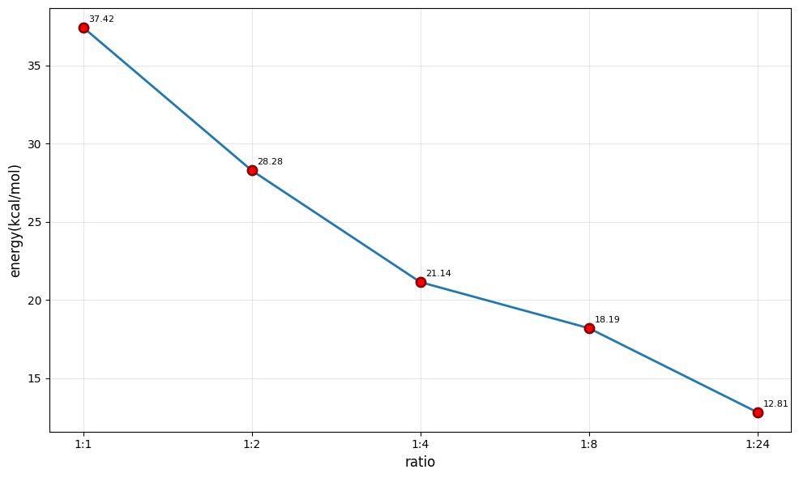

```python
plot_energy_changes(PHI_no_H=PHI_no_H,
                   H_PHI={'1:1': H_PHI_1_1,
                          '1:2': H_PHI_1_2,
                          '1:4': H_PHI_1_4,
                          '1:8': H_PHI_1_8,
                          '1:24': H_PHI_1_24},
                   h2o=H2O,
                   c2h4o=C2H4O,
                   Et2NH=Et2NH,
                   Et3N=Et3N
                   )
```

## The effect of the location of e−/H+ couples on stability

### Load the H-PHI (ratio 1:8)

```python
# the ratio of e−/H+ couples to heptazine is 1:8
H_PHI_1_8_bulk = ml.molecule.load('surface_to_bulk/H-PHI_1-8_bulk/gaussian.log', format='gaussian')

H_PHI_1_8_surface = ml.molecule.load('surface_to_bulk/H-PHI_1-8_surface/gaussian.log', format='gaussian')
```

### When hydrogen is in the bulk

```python
result_summary(H_PHI_1_8_bulk)
```

```
Total energy: -981.7228590000000 Hartree
ZPE:           2.7632650 Hartree
H:            -978.6890510 Hartree
G:            -979.2645920 Hartree

XYZ coordinates in Angstrom

435

C            -5.1367922469000           6.6282528086000          -1.4923778287000
C            -6.0684413646000           4.6081755346000          -1.9101997770000
C            -3.8158222629000           4.6450902139000          -1.8413170992000
C            -4.0534857308000           8.5844830312000          -1.1613386350000
C            -2.7379166100000           6.7808529694000          -1.5431365144000
C            -1.5635829522000           4.8864173178000          -1.8389806538000
N            -6.2297645538000           5.9075195619000          -1.6400616925000
N            -5.2081631672000           7.9197126774000          -1.2440638117000
N            -4.9270445504000           3.9515520030000          -2.0098014359000
N            -3.8967413539000           6.0186587357000          -1.6286375978000
N            -2.8299350978000           8.0740717256000          -1.3238899614000
N            -2.6294944243000           4.0852320065000          -1.9227381455000
N            -1.5638378871000           6.1988137019000          -1.6903899740000
N            -0.3771728532000           4.2187968463000          -1.9424156609000
C             0.8911525577000           4.6809942937000          -2.1353818654000
N             1.7815511994000           3.6974242438000          -2.2962353647000
C             3.0211891796000           4.0371606032000          -2.5719374797000
C             2.3724005137000           6.3522785720000          -2.4473170318000
N             3.3491174645000           5.3865220171000          -2.6617388143000
C             4.6404753620000           5.7650616488000          -3.0009136997000
N             1.1323279618000           5.9807559500000          -2.1905726697000
N             4.9425137896000           7.0424870018000          -3.1000720941000
N             2.6942354385000           7.6245629128000          -2.5472333623000
N             5.5409836056000           4.8346759414000          -3.2562249044000
N             3.9413293448000           3.1279053225000          -2.8258534561000
C             3.9608523392000           7.9150191143000          -2.8566703964000
C             5.1427369845000           3.5652312055000          -3.1447034783000
H            -0.4671403305000           3.2092780487000          -2.0000175232000
N            -4.1239172866000           9.8925505196000          -0.8905171364000
N             4.2739745408000           9.2130187615000          -2.9392562548000
H            -3.2694189827000          10.4178644438000          -0.8262754691000
```

[output cut: 389 more lines]

```
N             4.7758870098000          -3.6450593385000           3.6705469626000
H             3.8727116791000          -3.2077891324000           3.8219440832000
N             6.7333317840000           2.8494334633000           2.5133417068000
H             7.5735452296000           3.4142889576000           2.4575119044000
N            -6.6750584233000           1.4457361937000           3.6584035533000
H            -7.6007206756000           1.8586363688000           3.6984980597000
N             7.9609939987000          -9.6088794959000           2.4887523718000
H             8.8347240066000          -9.1837323204000           2.7430548703000
H             7.8970170559000         -10.5914226974000           2.2917733286000
N            -5.2839914409000         -10.3517220795000           0.3063989173000
H            -6.1122569831000          -9.8594062884000           0.0019550010000
H            -4.8582020382000         -10.9660048053000          -0.3702802970000
H            10.5912277540000           3.1083176005000          -1.0745055936000
H             0.3531134713000          -3.3925839547000           0.4522399856000
H           -10.5427846299000           2.5473350752000           0.3696794018000
```

3Dmol.js failed to load for some reason. Please check your browser console for error messages.

### When hydrogen is in the surface

```python
result_summary(H_PHI_1_8_surface)
```

```
Total energy: -981.7291645000000 Hartree
ZPE:           2.7691070 Hartree
H:            -978.6931070 Hartree
G:            -979.2573050 Hartree

XYZ coordinates in Angstrom

435

C            -2.1461271962000           6.1781460250000          -2.4446706599000
C            -2.6144311018000           3.9581771063000          -2.5854956727000
C            -0.4362037233000           4.5213179551000          -2.7651945288000
C            -1.5114700257000           8.3401090409000          -2.2630803830000
C             0.1513793206000           6.8661582272000          -2.6697666449000
C             1.7018562479000           5.2526455055000          -2.9338016261000
N            -3.0513703021000           5.2154298886000          -2.4431649151000
N            -2.4949188755000           7.4322257541000          -2.2645818893000
N            -1.3585877448000           3.5803526033000          -2.7540054711000
N            -0.8083687978000           5.8544189339000          -2.6262803517000
N            -0.2190866091000           8.1105433354000          -2.5139010680000
N             0.8399986624000           4.2323830698000          -2.9064874887000
N             1.4183858100000           6.5387583558000          -2.8702492783000
N             3.0028221664000           4.8428364362000          -3.0159191782000
C             4.1522066646000           5.5682667927000          -2.9637560609000
N             5.2420664953000           4.8104022929000          -2.8156224625000
C             6.3987912917000           5.4253182726000          -2.7020426026000
C             5.2686889061000           7.5301892804000          -2.9782322878000
N             6.4429059390000           6.8117126857000          -2.7907810744000
C             7.6552524039000           7.4766456215000          -2.6381704736000
N             4.1173491470000           6.8881101431000          -3.0559473583000
N             7.6856857220000           8.7885489133000          -2.7253019326000
N             5.3258564180000           8.8390509817000          -3.0882065882000
N             8.7555581548000           6.7756972402000          -2.4478043001000
N             7.5139503497000           4.7507168242000          -2.5146207042000
C             6.5273901123000           9.4076946424000          -2.9509992789000
C             8.6327034668000           5.4470784230000          -2.4057743719000
H             3.1311503875000           3.8357276924000          -2.9741150088000
N            -1.8640132127000           9.6105159277000          -2.0489417225000
N             6.5624709144000          10.7494450436000          -3.0117903100000
H            -1.1183441234000          10.2647847155000          -1.8875708749000
```

[output cut: 389 more lines]

```
N            -0.0127447109000          -2.9700586857000           3.1577164259000
H            -0.8148832853000          -2.3714739106000           2.9940306677000
N             3.4268337007000           3.0017094056000           2.9860431069000
H             4.3606703995000           3.3649285574000           2.8318979693000
N            -9.9013108975000           4.6955013471000           2.1697130116000
H           -10.7157594753000           5.2808089485000           2.0250677914000
N             1.8630300608000          -9.5960497069000           3.4865940368000
H             2.8275332187000          -9.3063442628000           3.4705181408000
H             1.6285827978000         -10.5283364705000           3.1896616789000
N           -10.1466238532000          -6.2659339530000          -1.8665120451000
H           -10.6898277597000          -5.4677050355000          -2.2301068069000
H            -9.8867625502000          -7.0107677745000          -2.4915110695000
H           -14.5467980648000           1.9796828406000           1.5140172419000
H            -4.6591543073000          -5.5035400873000           2.4483378953000
H             6.6715439944000          -0.5120146359000           3.3970749693000
```

3Dmol.js failed to load for some reason. Please check your browser console for error messages.

### The difference of Gidds Free Energy between the two structure

```python
diff_G = (H_PHI_1_8_surface.G - H_PHI_1_8_bulk.G) * 627.51
print(f'When the hydrogen is in the surface, the Gidds Free Energy is {diff_G} kcal/mol higher than when the hydrogen is in the bulk.')
```

```
When the hydrogen is in the surface, the Gidds Free Energy is 4.57266537001215 kcal/mol higher than when the hydrogen is in the bulk.
```